# Projet GMM5 2017

### with log transformation (but not paired)

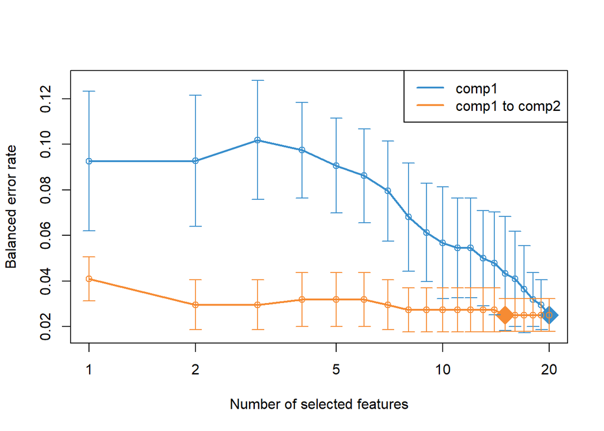

```r
set.seed(33)
res_plsda <- tune.splsda(log(t(abundances)+1), condition,
                         ncomp = nlevels(condition),
                         test.keepX = 1:20, validation = 'Mfold',
                         folds = 10, dist = 'mahalanobis.dist', nrepeat = 10,
                         progressBar = FALSE)

plot(res_plsda)
```

```r
sel_keepX <- res_plsda$choice.keepX[1:2]
sel_keepX
```

```
## comp1 comp2
##    20    15
```

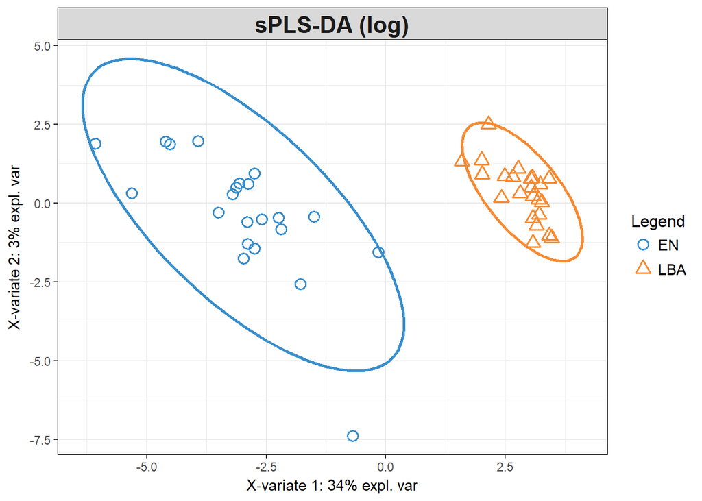

```r
res_splsda <- splsda(log(t(abundances)+1), condition,
                     ncomp = nlevels(condition), keepX = sel_keepX)

plotIndiv(res_splsda, comp = c(1,2), ind.names = FALSE, ellipse = TRUE,
          legend = TRUE, title = 'sPLS-DA (log)')
```

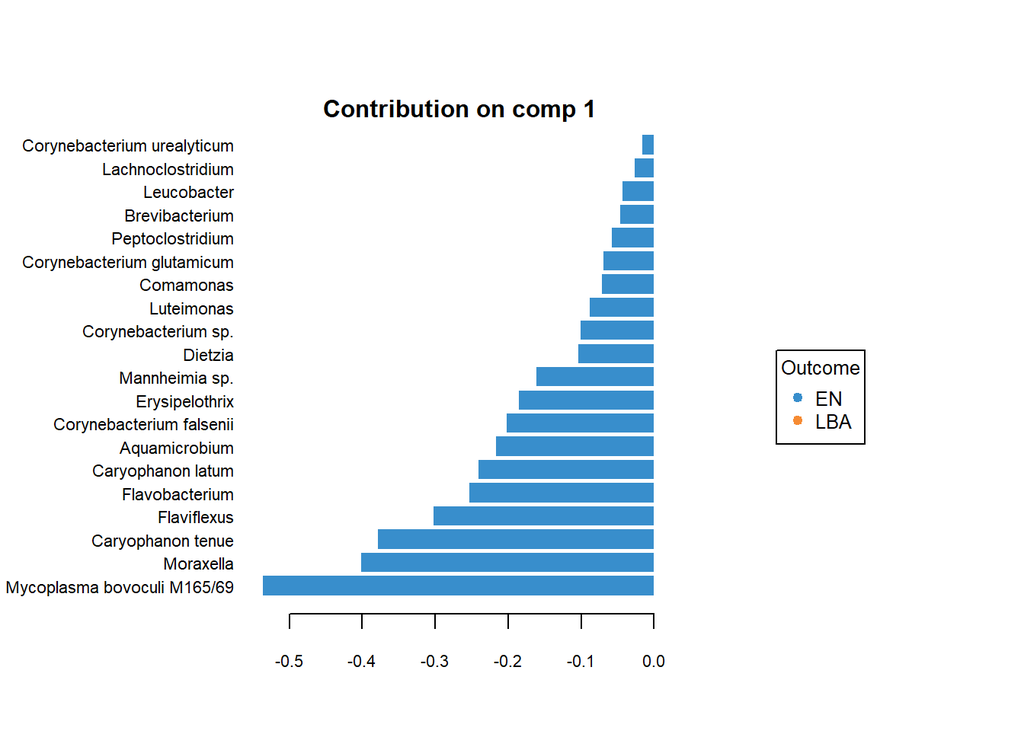

```r
plotLoadings(res_splsda, comp = 1, method = 'mean', contrib = 'max',
             size.title = 1)
```

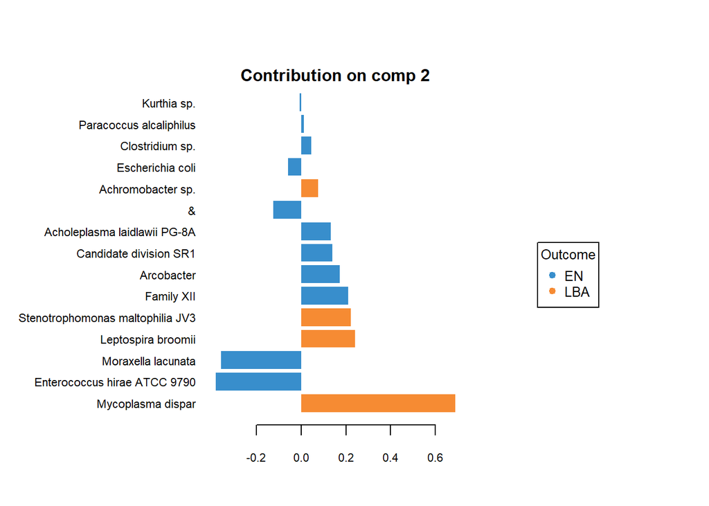

```r
plotLoadings(res_splsda, comp = 2, method = 'mean', contrib = 'max',
             size.title = 1)
```

### with TSS+CLR transformation (not paired)

```r
set.seed(11)
res_plsda <- plsda(abundances_CLR, condition, ncomp = nlevels(condition))
res_perf <- perf(res_plsda, validation = 'Mfold', folds = 5,
                 progressBar = FALSE, nrepeat = 20)
plot(res_perf, overlay = 'measure', sd = TRUE)
plotIndiv(res_plsda , comp = c(1, 2), ind.names = FALSE, ellipse = TRUE,
          legend = TRUE, title = 'PLS-DA (CLR)')
```

[output not shown]

```r
set.seed(33)
res_plsda <- tune.splsda(abundances_CLR, condition, ncomp = nlevels(condition),
                         test.keepX = 1:20, validation = 'Mfold',
                         folds = 10, dist = 'mahalanobis.dist', nrepeat = 10,
                         progressBar = F)

plot(res_plsda)

sel_keepX <- res_plsda$choice.keepX[1:2]
sel_keepX
```

[output not shown]

```r
res_splsda <- splsda(abundances_CLR, condition, ncomp = nlevels(condition),
                     keepX = sel_keepX)

plotIndiv(res_splsda, comp = c(1,2), ind.names = FALSE, ellipse = TRUE,
          legend = TRUE, title = 'sPLS-DA (CLR)')
```

[output not shown]

```r
plotLoadings(res_splsda, comp = 1, method = 'mean', contrib = 'max',
             size.title = 1)
plotLoadings(res_splsda, comp = 2, method = 'mean', contrib = 'max',
             size.title = 1)
```

[output not shown]

# Random Forest

In this section will be performed **Random Forest** algorithm for classification, with a virus as response vector and all bacteria as explanatory variables in the model.

```r
library(randomForest,quietly=T)
```

**Data preparation:**

```r
df_pathogenes<-read.delim("../data/pathogenes.csv",sep = ",")
pathogenes<-df_pathogenes[,-c(1,9)]
pathogenes<-as.data.frame(ifelse(pathogenes=='p',1,0))
pathogenes<-as.data.frame(apply(t(pathogenes),1,as.factor))
id_pathogenes<-df_pathogenes[,1]
id_pathogenes <- gsub("-","0",id_pathogenes)
id_pathogenes <- gsub(" ","",id_pathogenes)
id_pathogenes <- sapply(as.character(id_pathogenes),FUN=function(x){substr(x,nchar(x)-1,nchar(x))})
id_pathogenes <- id_pathogenes[id_pathogenes!="29"]
id_pathogenes <- paste0(id_pathogenes,"_",rev(condition[id_abundances!="29"]))
```

The list of calf names is not in the same order in the `pathogenes` file as in the `abundances` file. The `abundances` file order will be kept:

```r
id_abundances_bis <- paste0(id_abundances[-grep("29",id_abundances)],"_",
                            condition[-grep("29",id_abundances)])
pathogenes <- pathogenes[df_pathogenes[,1]!="ICSA-29",]
Y<-pathogenes[match(id_abundances_bis,id_pathogenes),]
rownames(Y)<-id_abundances_bis
```

`Y` contains the seven response vectors.

```r
cat(" 0  1\n\n")
```

```
##  0  1
```

```r
for (virus in colnames(Y)){
  cat(virus,"\n",table(Y[,virus]),fill=T)
}
```

```
## Ct.RSV
##  37 7
## Ct.PI.3
##  41 3
## Ct.Coronavirus
##  22 22
## Ct.P.multocida
##  6 38
## Ct.M.haemolytica
##  31 13
## Ct.M.bovis
##  39 5
## Ct.H.somni
##  26 18
```

The bacteria names are too long for the plots, they will be renamed:

```r
X <- clean_log
X <- as.data.frame(sapply(X,as.integer))
colnames(X)<- make.names(names(X))
```

## Random Forest on both conditions

### Random Forest on `RSV`:

```r
fit <- randomForest(Y$Ct.RSV ~ ., data = X,classwt=table(Y$Ct.RSV),ntree=3000)
fit$confusion
```

```
##    0 1 class.error
## 0 36 1  0.02702703
## 1  7 0  1.00000000
```

```r
varImpPlot(fit)
round(fit$importance[order(fit$importance[, 1], decreasing = TRUE), ][1:5],3)
plot(fit$err.rate[, 1], type = "l", xlab = "number of trees", ylab = "error OOB")
```

```r
cat(fit$predicted)
```

### Random Forest on `PI.3`:

```r
fit <- randomForest(Y$Ct.PI.3 ~ ., data = X,classwt=table(Y$Ct.PI.3),ntree=1000,mtry=10)
fit$confusion
```

```
##    0 1 class.error
## 0 41 0           0
## 1  3 0           1
```

Nothing in class `1`…

```r
varImpPlot(fit)
round(fit$importance[order(fit$importance[, 1], decreasing = TRUE), ][1:5],3)
plot(fit$err.rate[, 1], type = "l", xlab = "number of trees", ylab = "error OOB")
```

### Random Forest on `Coronavirus`:

```r
fit <- randomForest(Y$Ct.Coronavirus ~ .,data = X,classwt=table(Y$Ct.Coronavirus)
                    , ntree=2000,mtry=16)
fit$confusion
```

```
##    0  1 class.error
## 0 10 12   0.5454545
## 1  7 15   0.3181818
```

High error

```r
varImpPlot(fit)
fit$importance[order(fit$importance[, 1], decreasing = TRUE), ][1:5]
plot(fit$err.rate[, 1], type = "l", xlab = "number of trees", ylab = "error OOB")
```

### Random Forest on `P.multocida`:

```r
fit <- randomForest(Y$Ct.P.multocida ~ ., data = X,classwt=table(Y$Ct.P.multocida),ntree=1000,mtry=16)
fit$confusion
```

```
##   0  1 class.error
## 0 0  6           1
## 1 0 38           0
```

Nothing in class `0`

```r
varImpPlot(fit)
fit$importance[order(fit$importance[, 1], decreasing = TRUE), ][1:5]
plot(fit$err.rate[, 1], type = "l", xlab = "nombre d'arbres", ylab = "erreur OOB")
```

### Random Forest on `M.haemolytica`:

```r
fit <- randomForest(Y$Ct.M.haemolytica ~ ., data = X,classwt=table(Y$Ct.M.haemolytica),ntree=1000,mtry=40)
fit$confusion
```

```
##    0 1 class.error
## 0 31 0           0
## 1 13 0           1
```

```r
varImpPlot(fit)
fit$importance[order(fit$importance[, 1], decreasing = TRUE), ][1:5]
plot(fit$err.rate[, 1], type = "l", xlab = "number of trees", ylab = "error OOB")
```

### Random Forest on `M.bovis`:

```r
fit <- randomForest(Y$Ct.M.bovis ~ ., data = X,classwt=table(Y$Ct.M.bovis) , ntree=500,mtry=40)
fit$confusion
```

```
##    0 1 class.error
## 0 39 0           0
## 1  5 0           1
```

```r
varImpPlot(fit)
fit$importance[order(fit$importance[, 1], decreasing = TRUE), ][1:5]
plot(fit$err.rate[, 1], type = "l", xlab = "number of trees", ylab = "error OOB")
```

### Random Forest on `H.somni`:

```r
fit <- randomForest(Y$Ct.H.somni ~ ., data = X,classwt=table(Y$Ct.H.somni),ntree=1000,mtry=16)
fit$confusion
```

```
##    0  1 class.error
## 0 23  3   0.1153846
## 1  7 11   0.3888889
```

```r
varImpPlot(fit)
fit$importance[order(fit$importance[, 1], decreasing = TRUE), ][1:5]
plot(fit$err.rate[, 1], type = "l", xlab = "number of trees", ylab = "error OOB")
```

## Random Forest on `EN` condition

Study only on EN condition samples

```r
X_EN<-X[grep("EN",colnames(abundances)),]
X_LBA<-X[grep("LBA",rownames(Y)),]
Y_EN<-Y[grep("EN",colnames(abundances)),]
Y_LBA<-Y[grep("LBA",rownames(Y)),]

clean_log_EN <- clean_log[grep("EN",rownames(clean_log)),]
clean_id_EN <- clean_id[grep("EN",names(clean_id))]
clean_log_LBA <- clean_log[grep("LBA",rownames(clean_log)),]
clean_id_LBA <- clean_id[grep("LBA",names(clean_id))]
```

### Random Forest on `RSV` - `EN` condition:

```r
fit <- randomForest(Y_EN$Ct.RSV ~ ., data = X_EN,classwt=table(Y_EN$Ct.H.somni), ntree=5000)
fit$confusion
```

```
##    0 1 class.error
## 0 21 0           0
## 1  0 0         NaN
```

### Random Forest on `PI.3` - `EN` condition:

```r
fit <- randomForest(Y_EN$Ct.PI.3 ~ ., data = X_EN,classwt=table(Y_EN$Ct.H.somni), ntree=5000)
fit$confusion
```

```
##    0 1 class.error
## 0 20 0           0
## 1  2 0           1
```

### Random Forest on `Coronavirus` - `EN` condition:

```r
fit <- randomForest(Y_EN$Ct.Coronavirus ~ ., data = X_EN,classwt=table(Y_EN$Ct.H.somni), ntree=5000)
fit$confusion
```

```
##   0  1 class.error
## 0 1  8   0.8888889
## 1 2 11   0.1538462
```

### Random Forest on `M.haemolytica` - `EN` condition:

```r
fit <- randomForest(Y_EN$Ct.M.haemolytica~ ., data = X_EN,classwt=table(Y_EN$Ct.H.somni), ntree=5000)
fit$confusion
```

```
##    0 1 class.error
## 0 12 2   0.1428571
## 1  8 0   1.0000000
```

### Random Forest on `M.bovis` - `EN` condition:

```r
fit <- randomForest(Y_EN$Ct.M.bovis~ ., data = X_EN,classwt=table(Y_EN$Ct.H.somni), ntree=5000)
fit$confusion
```

```
##    0 1 class.error
## 0 20 0           0
## 1  2 0           1
```

### Random Forest on `P.multocida` - `EN` condition:

```r
fit <- randomForest(Y_EN$Ct.P.multocida ~ ., data = X_EN,classwt=table(Y_EN$Ct.H.somni), ntree=5000)
fit$confusion
```

```
##   0  1 class.error
## 0 0  2           1
## 1 0 20           0
```

### Random Forest on `H.somni` - `EN` condition:

```r
fit <- randomForest(Y_EN$Ct.H.somni ~ ., data = X_EN,classwt=table(Y_EN$Ct.H.somni), ntree=5000)
fit$confusion
```

```
##    0 1 class.error
## 0 12 1  0.07692308
## 1  3 6  0.33333333
```

# PLS-DA on viruses

## PLS-DA on `RSV`

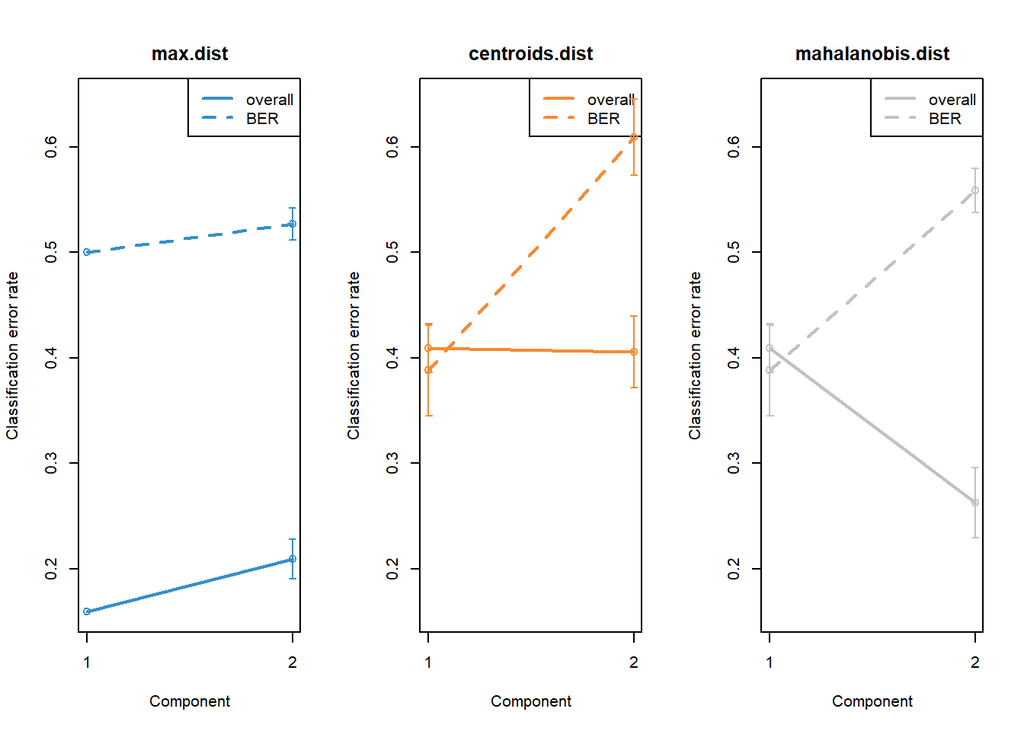

```r
set.seed(11)
res_plsda <- plsda(X=clean_log,Y=Y$Ct.RSV, ncomp = nlevels(clean_condition))
res_perf <- perf(res_plsda, validation = 'Mfold', folds = 5,
                 progressBar = FALSE, nrepeat = 20)
plot(res_perf, overlay = 'measure', sd = TRUE)
```

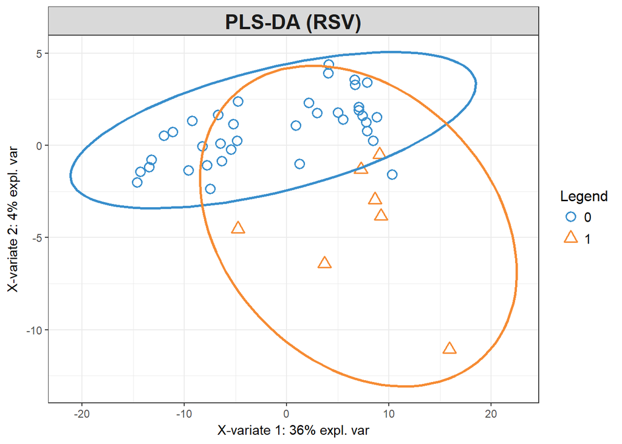

```r
plotIndiv(res_plsda , comp = c(1, 2), ind.names = FALSE, ellipse = TRUE,
          legend = TRUE, title = 'PLS-DA (RSV)')
```

```r
set.seed(33)
res_plsda <- tune.splsda(X=clean_log,Y=Y$Ct.RSV,
                         ncomp = nlevels(clean_condition),
                         multilevel = clean_id,
                         test.keepX = 1:20, validation = 'Mfold',
                         folds = 10, dist = 'mahalanobis.dist', nrepeat = 10,
                         progressBar = F)
```

```
## Splitting the variation for 1 level factor.
```

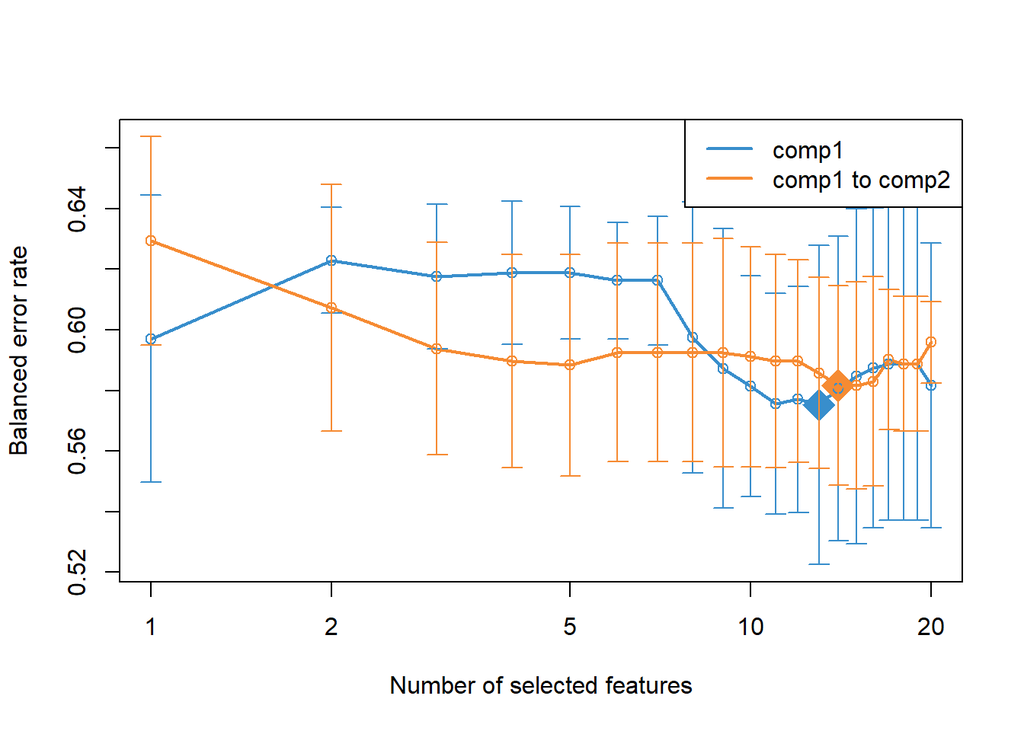

```r
plot(res_plsda)
```

```r
sel_keepX <- res_plsda$choice.keepX[1:2]
sel_keepX
```

```
## comp1 comp2
##    13    14
```

```r
res_splsda <- splsda(X=clean_log,Y=Y$Ct.RSV,
                     ncomp = nlevels(clean_condition),
                     multilevel = clean_id,
                     keepX = sel_keepX)
```

```
## Splitting the variation for 1 level factor.
```

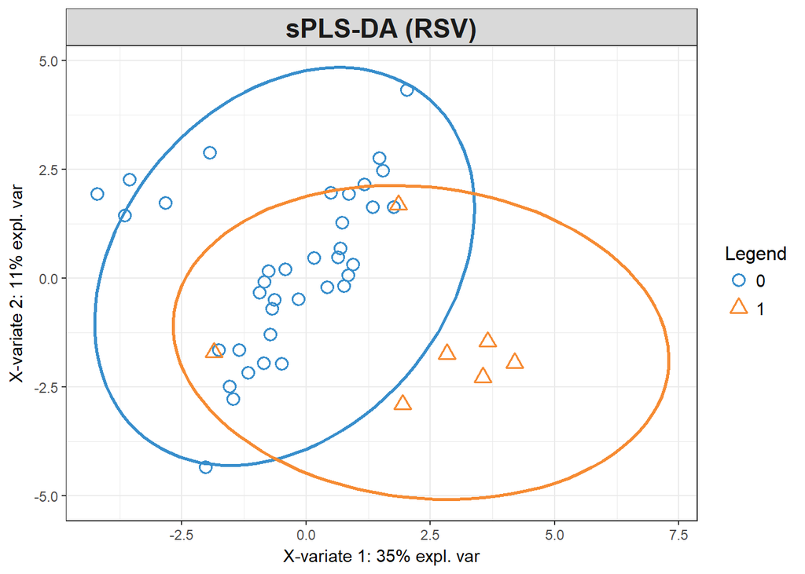

```r
plotIndiv(res_splsda, comp = c(1,2), ind.names = FALSE, ellipse = TRUE,
          legend = TRUE, title = 'sPLS-DA (RSV)')
```

```r
test <- predict(res_splsda,clean_log)
pred <- test$class$mahalanobis.dist[,2]
get.confusion_matrix(Y$Ct.RSV,predicted=pred)
```

```
##   predicted.as.0 predicted.as.1
## 0             36              1
## 1              6              1
```

```r
head(selectVar(res_splsda, comp = 1)$name)
```

```
## [1] "Lactococcus lactis"         "Saccharibacteria"
## [3] "Moheibacter"                "Streptococcus gallolyticus"
## [5] "Facklamia"                  "Flavobacterium"
```

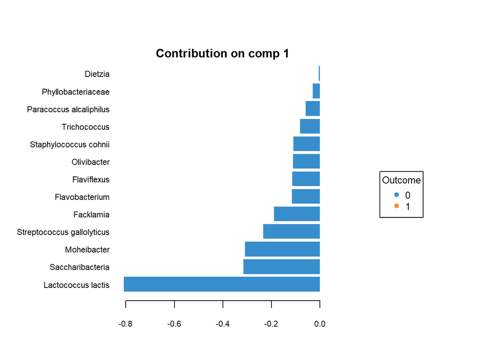

```r
plotLoadings(res_splsda, comp = 1, method = 'mean', contrib = 'max',
             size.title = 1)
```

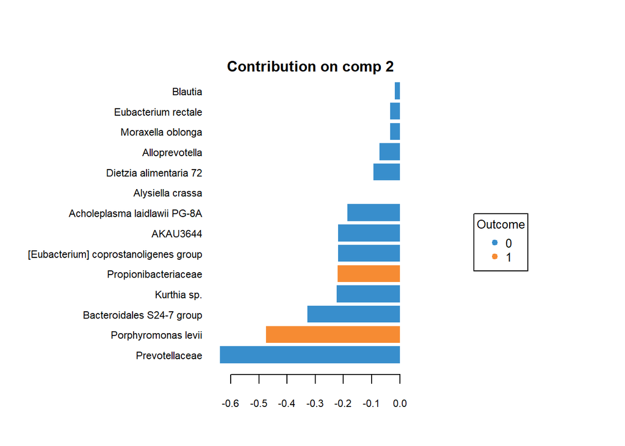

```r
plotLoadings(res_splsda, comp = 2, method = 'mean', contrib = 'max',
             size.title = 1)
```